# lab8 part2

1. From the results in Part1, the worst performing trained model is the model trained with 250 dataset, and the best performing trained model is the model trained with 5000 dataset. So these two model is chosen. And firstly, the CNN is trained again using the two different dataset.

```python
import torch
import torch.nn as nn
import torchvision
import torchvision.transforms as transforms
import torchvision.datasets as datasets


# Device configuration
device = torch.device('cuda:0' if torch.cuda.is_available() else 'cpu')

# Hyper parameters
num_epochs = 5
num_classes = 10
batch_size = 100
learning_rate = 0.001

# MNIST dataset
#train_dataset = torchvision.datasets.MNIST(root='./data/',
#                                           train=True,
#                                           transform=transforms.ToTensor(),
#                                           download=True)

#test_dataset = torchvision.datasets.MNIST(root='./data/',
#                                         train=False,
#                                          transform=transforms.ToTensor())
train_worst, temp_worst = torch.utils.data.random_split(torchvision.datasets.MNIST(root='./data/',
                                                                        train = True,
                                                                        transform=transforms.ToTensor(),download=True),
                                                                        [250,59750])
train_best, temp_best = torch.utils.data.random_split(torchvision.datasets.MNIST(root='./data/',
                                                                        train = True,
                                                                        transform=transforms.ToTensor(),download=True),
                                                                        [5000,55000])
test_dataset, temp_dataset = torch.utils.data.random_split(torchvision.datasets.MNIST(root='./data/',
                                                                        train = False,
                                                                        transform=transforms.ToTensor(),download=True),
                                                                        [10000,0])
```

```python
# Data loader
train_loader_worst = torch.utils.data.DataLoader(dataset=train_worst,
                                           batch_size=batch_size,
                                           shuffle=True)
train_loader_best = torch.utils.data.DataLoader(dataset=train_best,
                                           batch_size=batch_size,
                                           shuffle=True)
test_loader = torch.utils.data.DataLoader(dataset=test_dataset,
                                           batch_size=batch_size,
                                           shuffle=True)
```

```python
print(len(train_loader_worst))
print(len(train_loader_best))
print(len(test_loader))
```

```
3
50
100
```

1. Construct the Convolutional neural network.

```python
# Convolutional neural network (two convolutional layers)
class ConvNet(nn.Module):
    def __init__(self, num_classes=10):
        super(ConvNet, self).__init__()
        self.layer1 = nn.Sequential(
            nn.Conv2d(1, 16, kernel_size=5, stride=1, padding=2),
            nn.BatchNorm2d(16),
            nn.ReLU(),
            nn.MaxPool2d(kernel_size=2, stride=2))
        self.layer2 = nn.Sequential(
            nn.Conv2d(16, 32, kernel_size=5, stride=1, padding=2),
            nn.BatchNorm2d(32),
            nn.ReLU(),
            nn.MaxPool2d(kernel_size=2, stride=2))
        self.fc = nn.Linear(7*7*32, num_classes)

    def forward(self, x):
        out = self.layer1(x)
        out = self.layer2(out)
        out = out.reshape(out.size(0), -1)
        out = self.fc(out)
        return out

model = ConvNet(num_classes).to(device)
```

```python
# Loss and optimizer
criterion = nn.CrossEntropyLoss()
optimizer = torch.optim.Adam(model.parameters(), lr=learning_rate)
```

1. Get the MNIST train dataset

```python
mnist_trainset = datasets.MNIST(root='./data', train=True, download=True, transform=None)
len(mnist_trainset)
print(mnist_trainset)
```

```
Dataset MNIST
    Number of datapoints: 60000
    Root location: ./data
    Split: Train
```

1. Get the MNIST test dataset.

```python
mnist_testset = datasets.MNIST(root='./data', train=False, download=True, transform=None)
len(mnist_testset)
```

```
10000
```

```python
data0 = mnist_testset[0]
img = data0[0]
print (img)
print (data0[1])
```

```
<PIL.Image.Image image mode=L size=28x28 at 0x10C76B160>
7
```

```python
display(img)
```

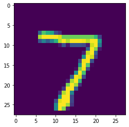

```python
%matplotlib inline
from matplotlib.pyplot import imshow
import numpy as np
from PIL import Image
imshow(np.asarray(data0[0]));
```

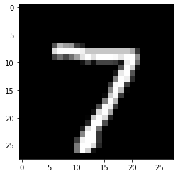

```python
imshow(np.asarray(img), cmap='gray');
```

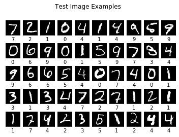

```python
import matplotlib.pyplot as plt
for i in range(50):
    ximg = np.asarray(mnist_testset[i][0])
    l1_plot = plt.subplot(5, 10, i + 1)
    l1_plot.imshow(ximg, interpolation='nearest', cmap=plt.cm.gray)
    l1_plot.set_xticks(())
    l1_plot.set_yticks(())
    l1_plot.set_xlabel('%i' % int(mnist_testset[i][1]))
plt.suptitle('Test Image Examples')
plt.show()
```

1. Train the CNN model with the 250 train dataset.

```python
# Train the model with 250 data
total_step = len(train_loader_worst)
for epoch in range(num_epochs):
    for i, (images, labels) in enumerate(train_loader_worst):
        images = images.to(device)
        labels = labels.to(device)

        # Forward pass
        outputs = model(images)
        loss = criterion(outputs, labels)

        # Backward and optimize
        optimizer.zero_grad()
        loss.backward()
        optimizer.step()

        if (i+1) % 1 == 0:
            print ('Epoch [{}/{}], Step [{}/{}], Loss: {:.4f}'
                   .format(epoch+1, num_epochs, i+1, total_step, loss.item()))
```

```
Epoch [1/5], Step [1/3], Loss: 2.5889
Epoch [1/5], Step [2/3], Loss: 2.2894
Epoch [1/5], Step [3/3], Loss: 2.0931
Epoch [2/5], Step [1/3], Loss: 1.7344
Epoch [2/5], Step [2/3], Loss: 1.4496
Epoch [2/5], Step [3/3], Loss: 1.3974
Epoch [3/5], Step [1/3], Loss: 1.1497
Epoch [3/5], Step [2/3], Loss: 0.9639
Epoch [3/5], Step [3/3], Loss: 0.8099
Epoch [4/5], Step [1/3], Loss: 0.7184
Epoch [4/5], Step [2/3], Loss: 0.7258
Epoch [4/5], Step [3/3], Loss: 0.7274
Epoch [5/5], Step [1/3], Loss: 0.5679
Epoch [5/5], Step [2/3], Loss: 0.5148
Epoch [5/5], Step [3/3], Loss: 0.4159
```

1. Then test the trained model with the training dataset, which is the 250 dataset, and the accuracy is 83.2%.

```python
# Test the model with the worst trained
model.eval()  # eval mode (batchnorm uses moving mean/variance instead of mini-batch mean/variance)
with torch.no_grad():
    correct = 0
    total = 0
    for images, labels in train_loader_worst:
        images = images.to(device)
        labels = labels.to(device)
        outputs = model(images)
        _, predicted = torch.max(outputs.data, 1)
        total += labels.size(0)
        correct += (predicted == labels).sum().item()

print('Test Accuracy of the model on the 250 test images: {} %'.format(100 * correct / total))
```

```
Test Accuracy of the model on the 250 test images: 83.2 %
```

1. Then we need to test with my own dataset, first create a function which is used to be the local dataset loader. And call it to get my own dataset.

```python
""" Custom datatset loader
    based on https://github.com/utkuozbulak/pytorch-custom-dataset-examples
"""

import pandas as pd
from torch.utils.data.dataset import Dataset
from torchvision import transforms

class SimpleDataset(Dataset):
    def __init__(self, data_path, csv_name, transform = None ):
        """
        Args:
            data_path (string): path to the folder where images and csv files are located
            csv_name (string): name of the csv lablel file
            transform: pytorch transforms for transforms and tensor conversion
        """
        # Set path
        self.data_path = data_path
        # Transforms
        self.transform = transform
        # Read the csv file
        self.data_info = pd.read_csv(data_path + csv_name, header=None)
        # First column contains the image paths
        self.image_arr = np.asarray(self.data_info.iloc[:, 0])
        # Second column is the labels
        self.label_arr = np.asarray(self.data_info.iloc[:, 1])
        # Calculate len
        self.data_len = len(self.data_info.index)


    def __getitem__(self, index):
        # Get image name from the pandas df
        single_image_name = self.image_arr[index]
        # Open image
        img_as_img = Image.open(self.data_path + single_image_name)
        img_as_img = img_as_img.convert("L")
        if self.transform is not None:
              img_as_img = self.transform(img_as_img)

        # Get label(class) of the image based on the cropped pandas column
        single_image_label = self.label_arr[index]
        #convert to tensor to be consistent with MNIST dataset
        single_image_label = torch.LongTensor( [ single_image_label ] )[0]
        return (img_as_img, single_image_label)

    def __len__(self):
        return self.data_len

mydata = SimpleDataset( "/Users/louissmacbook/Desktop/idata/", "idata.csv")
len(mydata)
```

```
50
```

```python
mydata0 = mydata[0]
display(mydata0[0])
print (mydata0[1])
```

```
tensor(0)
```

1. Call the function above to get my own dataset and transform it to the Tensirflow format, which could speed up the testing procedure.

```python
mydataT = SimpleDataset( "/Users/louissmacbook/Desktop/idata/", "idata.csv", transform=transforms.ToTensor())
print(mydataT)
testc = mydataT[1]
testT = testc[0]
imgt = Image.fromarray((testT.numpy()[0] * 255).astype("uint8"))
display(imgt)
```

```
<__main__.SimpleDataset object at 0x10bb56940>
```

1. Then load the Tensorflow format testing data.

```python
own_test_loader = torch.utils.data.DataLoader(dataset=mydataT,
                                          batch_size=batch_size,
                                          shuffle=False)
```

1. Test the worst trained model with the Test dataset. And the accuracy is pretty low. One reason is that the CNN is not properly trained because of lack of sufficient training dataset. Another reason is that my handwriting style is not similar to the one who created the training dataset.

```python
# Test the model with the worst trained
model.eval()  # eval mode (batchnorm uses moving mean/variance instead of mini-batch mean/variance)
with torch.no_grad():
    correct = 0
    total = 0
    for images, labels in own_test_loader:
        images = images.to(device)
        labels = labels.to(device)
        outputs = model(images)
        _, predicted = torch.max(outputs.data, 1)
        total += labels.size(0)
        correct += (predicted == labels).sum().item()

print('Test Accuracy of the model on the own test images: {} %'.format(100 * correct / total))
```

```
Test Accuracy of the model on the own test images: 40.0 %
```

1. Then train the CNN model with the 5000 training dataset.

```python
# Train the model with 5000 data
total_step = len(train_loader_worst)
for epoch in range(num_epochs):
    for i, (images, labels) in enumerate(train_loader_best):
        images = images.to(device)
        labels = labels.to(device)

        # Forward pass
        outputs = model(images)
        loss = criterion(outputs, labels)

        # Backward and optimize
        optimizer.zero_grad()
        loss.backward()
        optimizer.step()

        if (i+1) % 10 == 0:
            print ('Epoch [{}/{}], Step [{}/{}], Loss: {:.4f}'
                   .format(epoch+1, num_epochs, i+1, total_step, loss.item()))
```

```
Epoch [1/5], Step [10/3], Loss: 0.8094
Epoch [1/5], Step [20/3], Loss: 0.3628
Epoch [1/5], Step [30/3], Loss: 0.3189
Epoch [1/5], Step [40/3], Loss: 0.2243
Epoch [1/5], Step [50/3], Loss: 0.2886
Epoch [2/5], Step [10/3], Loss: 0.3672
Epoch [2/5], Step [20/3], Loss: 0.2733
Epoch [2/5], Step [30/3], Loss: 0.2261
Epoch [2/5], Step [40/3], Loss: 0.2383
Epoch [2/5], Step [50/3], Loss: 0.3147
Epoch [3/5], Step [10/3], Loss: 0.1810
Epoch [3/5], Step [20/3], Loss: 0.0852
Epoch [3/5], Step [30/3], Loss: 0.2048
Epoch [3/5], Step [40/3], Loss: 0.2364
Epoch [3/5], Step [50/3], Loss: 0.2061
Epoch [4/5], Step [10/3], Loss: 0.1599
Epoch [4/5], Step [20/3], Loss: 0.1631
Epoch [4/5], Step [30/3], Loss: 0.1235
Epoch [4/5], Step [40/3], Loss: 0.0985
Epoch [4/5], Step [50/3], Loss: 0.1538
Epoch [5/5], Step [10/3], Loss: 0.0568
Epoch [5/5], Step [20/3], Loss: 0.1666
Epoch [5/5], Step [30/3], Loss: 0.0977
Epoch [5/5], Step [40/3], Loss: 0.0700
Epoch [5/5], Step [50/3], Loss: 0.2245
```

1. The test accuracy of the training 5000 dataset is 96.98%.

```python
# Test the model with the best trained
model.eval()  # eval mode (batchnorm uses moving mean/variance instead of mini-batch mean/variance)
with torch.no_grad():
    correct = 0
    total = 0
    for images, labels in train_loader_best:
        images = images.to(device)
        labels = labels.to(device)
        outputs = model(images)
        _, predicted = torch.max(outputs.data, 1)
        total += labels.size(0)
        correct += (predicted == labels).sum().item()

print('Test Accuracy of the model on the 5000 test images: {} %'.format(100 * correct / total))
```

```
Test Accuracy of the model on the 5000 test images: 96.98 %
```

1. Then test this best trained model with my own dataset.

```python
""" Custom datatset loader
    based on https://github.com/utkuozbulak/pytorch-custom-dataset-examples
"""

import pandas as pd
from torch.utils.data.dataset import Dataset
from torchvision import transforms

class SimpleDataset(Dataset):
    def __init__(self, data_path, csv_name, transform = None ):
        """
        Args:
            data_path (string): path to the folder where images and csv files are located
            csv_name (string): name of the csv lablel file
            transform: pytorch transforms for transforms and tensor conversion
        """
        # Set path
        self.data_path = data_path
        # Transforms
        self.transform = transform
        # Read the csv file
        self.data_info = pd.read_csv(data_path + csv_name, header=None)
        # First column contains the image paths
        self.image_arr = np.asarray(self.data_info.iloc[:, 0])
        # Second column is the labels
        self.label_arr = np.asarray(self.data_info.iloc[:, 1])
        # Calculate len
        self.data_len = len(self.data_info.index)


    def __getitem__(self, index):
        # Get image name from the pandas df
        single_image_name = self.image_arr[index]
        # Open image
        img_as_img = Image.open(self.data_path + single_image_name)
        img_as_img = img_as_img.convert("L")
        if self.transform is not None:
              img_as_img = self.transform(img_as_img)

        # Get label(class) of the image based on the cropped pandas column
        single_image_label = self.label_arr[index]
        #convert to tensor to be consistent with MNIST dataset
        single_image_label = torch.LongTensor( [ single_image_label ] )[0]
        return (img_as_img, single_image_label)

    def __len__(self):
        return self.data_len

mydata = SimpleDataset( "/Users/louissmacbook/Desktop/idata/", "idata.csv")
len(mydata)
```

```
50
```

```python
mydata0 = mydata[0]
display(mydata0[0])
print (mydata0[1])
```

```
tensor(0)
```

```python
mydataT = SimpleDataset( "/Users/louissmacbook/Desktop/idata/", "idata.csv", transform=transforms.ToTensor())
print(mydataT)
testc = mydataT[10]
testT = testc[0]
imgt = Image.fromarray((testT.numpy()[0] * 255).astype("uint8"))
display(imgt)
```

```
<__main__.SimpleDataset object at 0x12da67ba8>
```

```python
own_test_loader = torch.utils.data.DataLoader(dataset=mydataT,
                                          batch_size=batch_size,
                                          shuffle=False)
```

1. The accuracy is appeared to be 78%. Higher than before, but still not sufficient.

```python
# Test the model with the best trained with my own dataset
model.eval()  # eval mode (batchnorm uses moving mean/variance instead of mini-batch mean/variance)
with torch.no_grad():
    correct = 0
    total = 0
    for images, labels in own_test_loader:
        images = images.to(device)
        labels = labels.to(device)
        outputs = model(images)
        _, predicted = torch.max(outputs.data, 1)
        total += labels.size(0)
        correct += (predicted == labels).sum().item()

print('Test Accuracy of the model on the own test images: {} %'.format(100 * correct / total))
```

```
Test Accuracy of the model on the own test images: 78.0 %
```